# Assigment 3 - Aman kumar - 17025

Nef (Negative Regulatory Factor) is a small 27 35 kDa protein that is coded by the HIV genome.This gene performs several different tasks during infection. However, despite being studied for more than two decades, it was not known how this protein increases the infectivity of new virus particles released from the cell. In the year 2015, two groups of scientists independently solved this 20 year old mystery and shed light on a pair of new genes that could restrict HIV in absence of the Nef protein (Rosa et al. 2015; Usami et al. 2015).

I have use this following paper to replicate results from the paper:

Rosa A, Chande A, Ziglio S, De Sanctis V, Bertorelli R, Goh SL, McCauley SM, Nowosielska A, Antonarakis SE, Luban J, et al. 2015. HIV 1 Nef promotes infection by excluding SERINC5 from virion incorporation. Nature 526:212––217.217.

```r
getwd()
```

```
## [1] "D:/IISER BHOPAL/SEM 8/DSE 401/Assignment 3"
```

```r
#setwd("D:/IISER BHOPAL/SEM 8/DSE 401/Assignment 3")
#getwd()
```

## Loading the libraries

```r
#install.packages("psych")
```

```r
library(tidyverse)
library(dplyr)
library(tidyr)
library(Hmisc)
library(ggplot2)
library(psych)
library(factoextra)
library(devtools)
```

# Reading files

Loading Read-count files

```r
load_htseq <- list.files(pattern = "*.htseq")
all_samples <- lapply(load_htseq, read.delim, header=F)
all_samples <- as.data.frame(all_samples)
colnames(all_samples)<- c("MT4","MT4_count","HSB2","HSB2_count","HT1080","HT1080_count","RAJI","RAJI_count","CEM SS","CEM SS_count","DAUDI","DAUDI_count","C8166","C8166_count","RAMOS","RAMOS_count","IMR90","IMR90_count","CEM_A_301","CEM_A_301_count","CEM_X_174","CEM_X_174_count","WI38","WI38_count","JURKAT_E6.1","JURKAT_E6.1_count","bl41","bl41_count","Jurkat_tag","Jurkat_tag_count")
```

### Extracting only count columns

```r
samples <- all_samples[c(1, seq(2, 30, 2))]
colnames(samples)[1] <- c("Gene_ID")
```

### Loading Inactivity ratio file

```r
infect <- read.delim("infect.txt", sep="\t", header= F)
colnames(infect) <- c("accession_id", "infectivity_ratio", "cell_lines")
infect <- arrange(infect,accession_id)
```

## Data Visualization

```r
MT4 = read.delim("SRR2166624.htseq", header=F)
MT4 <- MT4[MT4$V2 != 0,]
MT4 <- MT4[-c(58303, 58304, 58305, 58306, 58307),]
```

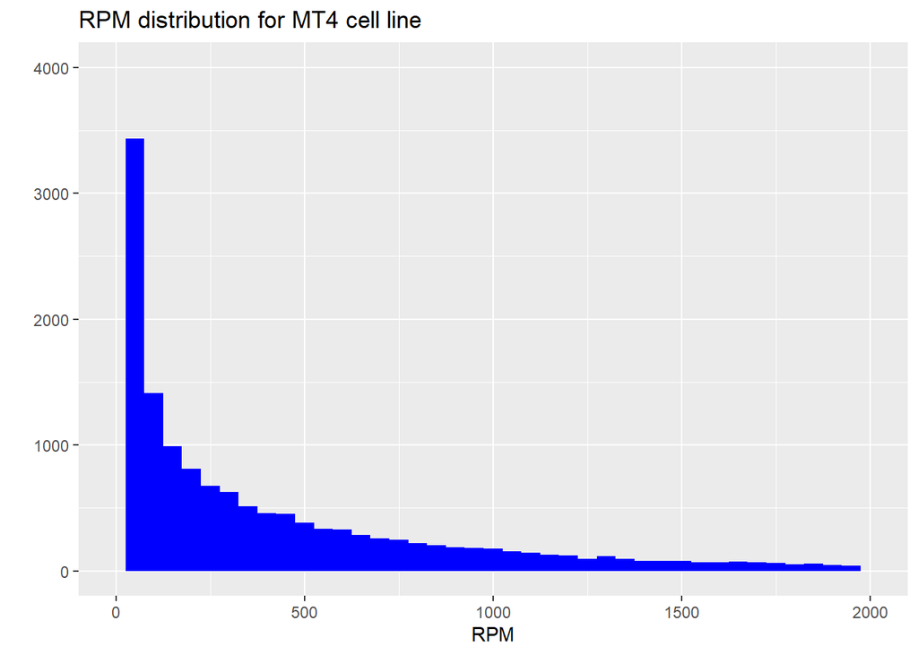

```r
qplot(MT4$V2,
      geom="histogram",
      binwidth = 50,
      main = "RPM distribution for MT4 cell line",
      xlab = "RPM",
      fill=I("blue"),
      xlim=c(0,2000),
      ylim=c(0,4000))
```

```r
HSB2 = read.delim("SRR2166625.htseq", header=F)
HSB2 <- HSB2[HSB2$V2 != 0,]
```

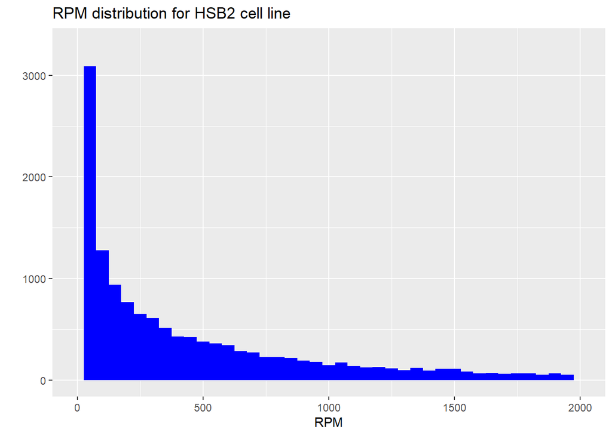

```r
qplot(HSB2$V2,
      geom="histogram",
      binwidth = 50,
      main = "RPM distribution for HSB2 cell line",
      xlab = "RPM",
      fill=I("blue"),
      xlim=c(0,2000),
      ylim=c(0,3300))
```

```r
HT1080 = read.delim("SRR2166626.htseq", header=F)
HT1080 <- HT1080[HT1080$V2 != 0,]
```

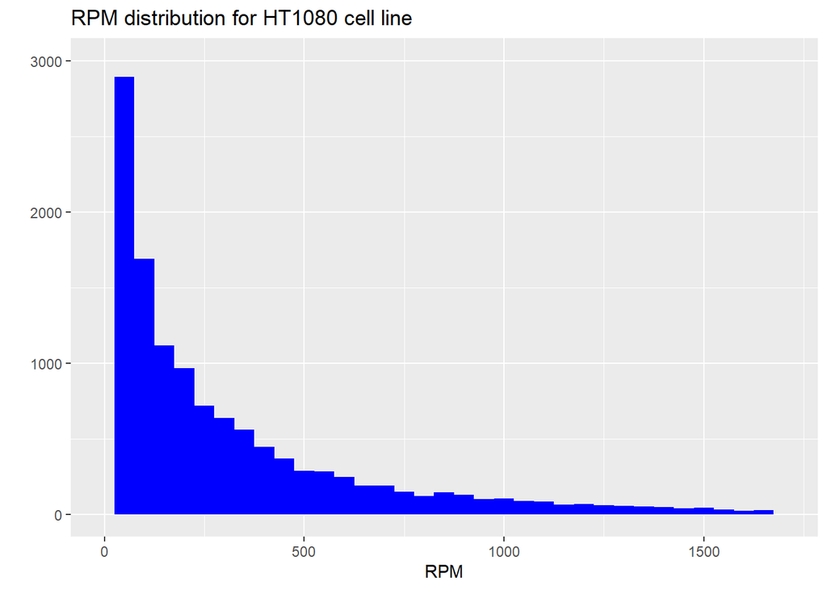

```r
qplot(HT1080$V2,
      geom="histogram",
      binwidth = 50,
      main = "RPM distribution for HT1080 cell line",
      xlab = "RPM",
      fill=I("blue"),
      xlim=c(0,1700),
      ylim=c(0,3000))
```

```r
RAJI = read.delim("SRR2166627.htseq", header=F)
RAJI <- RAJI[RAJI$V2 != 0,]
```

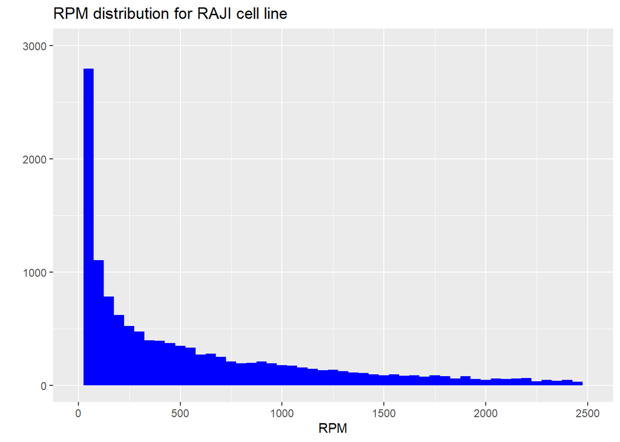

```r
qplot(RAJI$V2,
      geom="histogram",
      binwidth = 50,
      main = "RPM distribution for RAJI cell line",
      xlab = "RPM",
      fill=I("blue"),
      xlim=c(0,2500),
      ylim=c(0,3000))
```

```r
cell_line = read.delim("SRR2166628.htseq", header=F)
cell_line <- cell_line[cell_line$V2 != 0,]
```

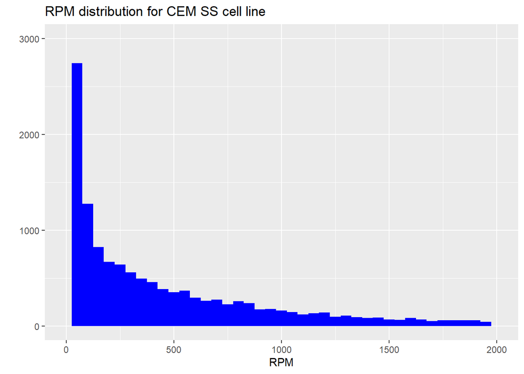

```r
qplot(cell_line$V2,
      geom="histogram",
      binwidth = 50,
      main = "RPM distribution for CEM SS cell line",
      xlab = "RPM",
      fill=I("blue"),
      xlim=c(0,2000),
      ylim=c(0,3000))
```

```r
cell_line = read.delim("SRR2166629.htseq", header=F)
cell_line <- cell_line[cell_line$V2 != 0,]
```

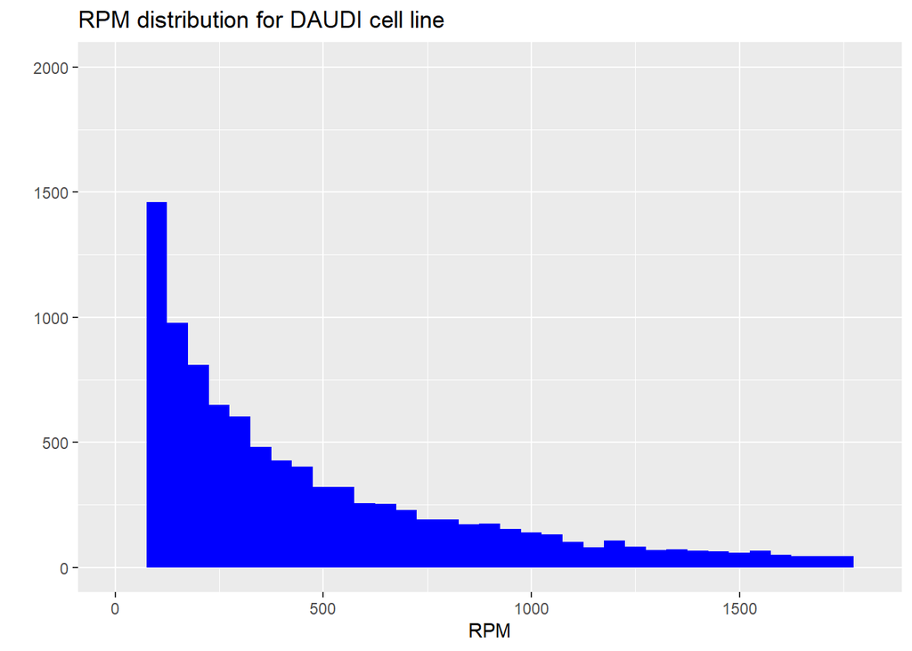

```r
qplot(cell_line$V2,
      geom="histogram",
      binwidth = 50,
      main = "RPM distribution for DAUDI cell line",
      xlab = "RPM",
      fill=I("blue"),
      xlim=c(0,1800),
      ylim=c(0,2000))
```

```r
cell_line = read.delim("SRR2166630.htseq", header=F)
cell_line <- cell_line[cell_line$V2 != 0,]
```

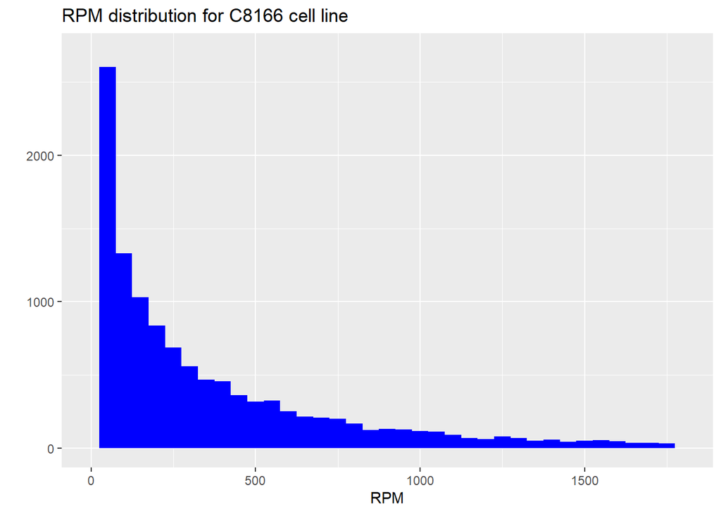

```r
qplot(cell_line$V2,
      geom="histogram",
      binwidth = 50,
      main = "RPM distribution for C8166 cell line",
      xlab = "RPM",
      fill=I("blue"),
      xlim=c(0,1800),
      ylim=c(0,2700))
```

```r
cell_line = read.delim("SRR2166631.htseq", header=F)
cell_line <- cell_line[cell_line$V2 != 0,]
```

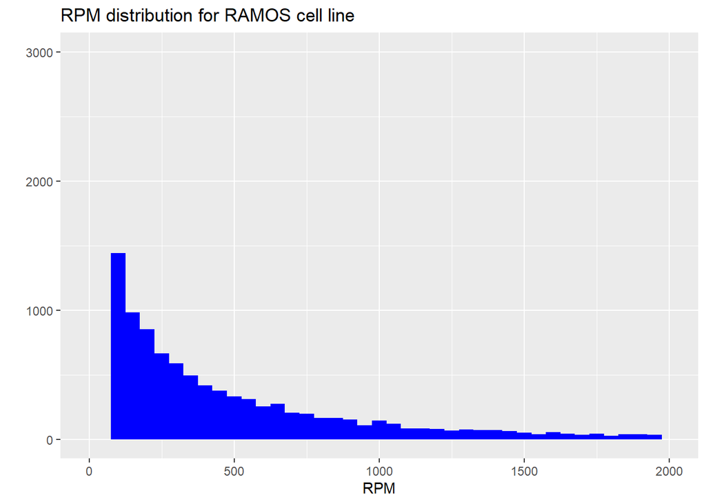

```r
qplot(cell_line$V2,
      geom="histogram",
      binwidth = 50,
      main = "RPM distribution for RAMOS cell line",
      xlab = "RPM",
      fill=I("blue"),
      xlim=c(0,2000),
      ylim=c(0,3000))
```

```r
cell_line = read.delim("SRR2166632.htseq", header=F)
cell_line <- cell_line[cell_line$V2 != 0,]
```

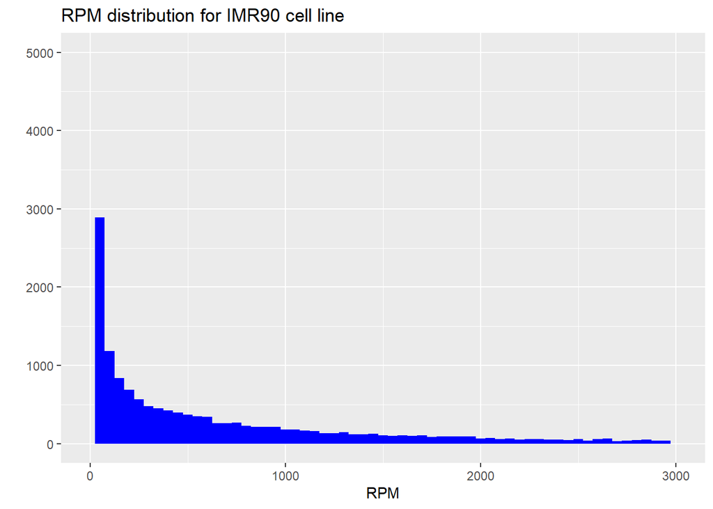

```r
qplot(cell_line$V2,
      geom="histogram",
      binwidth = 50,
      main = "RPM distribution for IMR90 cell line",
      xlab = "RPM",
      fill=I("blue"),
      xlim=c(0,3000),
      ylim=c(0,5000))
```

```r
cell_line = read.delim("SRR2166633.htseq", header=F)
cell_line <- cell_line[cell_line$V2 != 0,]
```

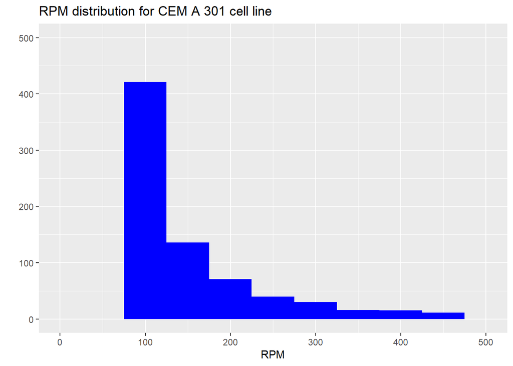

```r
qplot(cell_line$V2,
      geom="histogram",
      binwidth = 50,
      main = "RPM distribution for CEM A 301 cell line",
      xlab = "RPM",
      fill=I("blue"),
      xlim=c(0,500),
      ylim=c(0,500))
```

```r
cell_line = read.delim("SRR2166634.htseq", header=F)
cell_line <- cell_line[cell_line$V2 != 0,]
```

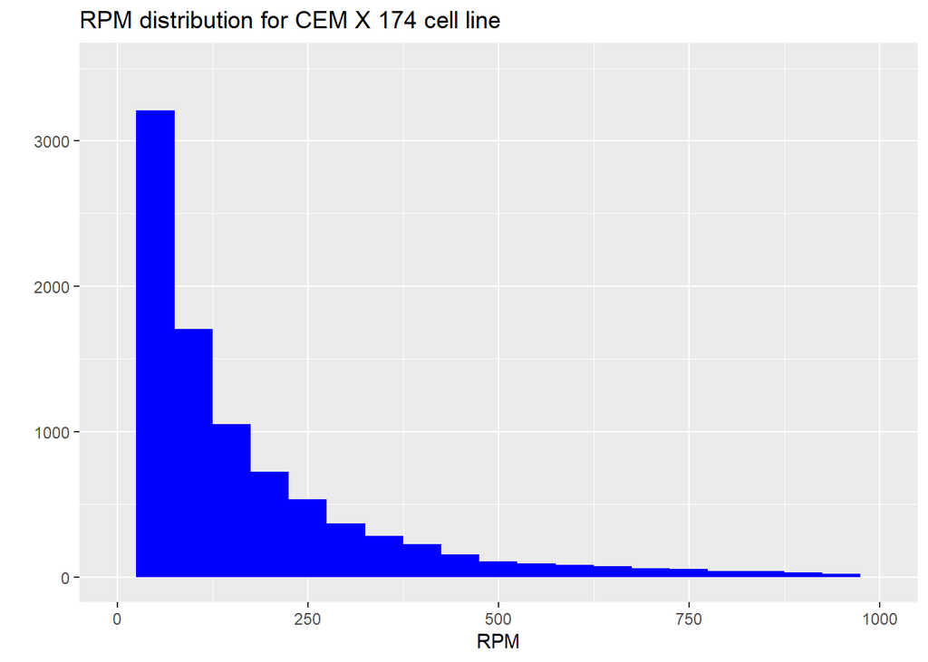

```r
qplot(cell_line$V2,
      geom="histogram",
      binwidth = 50,
      main = "RPM distribution for CEM X 174 cell line",
      xlab = "RPM",
      fill=I("blue"),
      xlim=c(0,1000),
      ylim=c(0,3500))
```

```r
cell_line = read.delim("SRR2166635.htseq", header=F)
cell_line <- cell_line[cell_line$V2 != 0,]
```

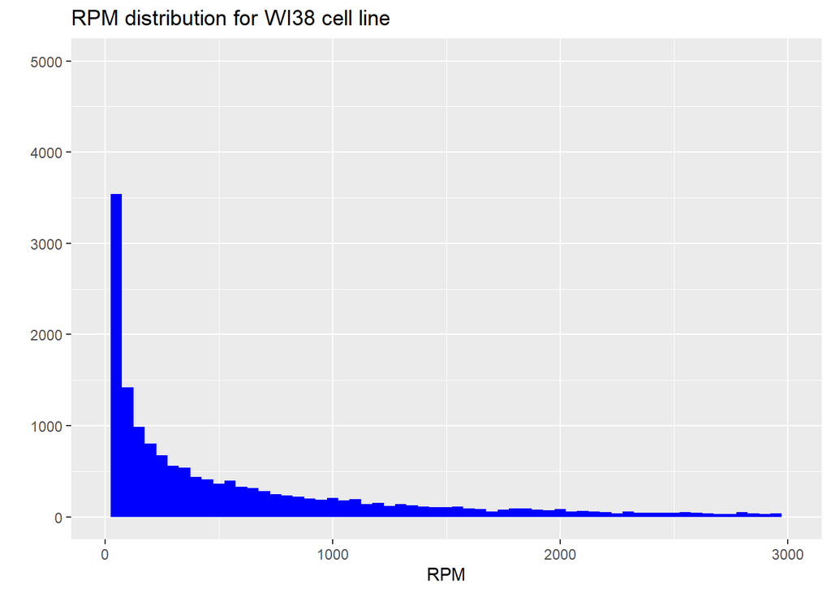

```r
qplot(cell_line$V2,
      geom="histogram",
      binwidth = 50,
      main = "RPM distribution for WI38 cell line",
      xlab = "RPM",
      fill=I("blue"),
      xlim=c(0,3000),
      ylim=c(0,5000))
```

```r
cell_line = read.delim("SRR2166636.htseq", header=F)
cell_line <- cell_line[cell_line$V2 != 0,]
```

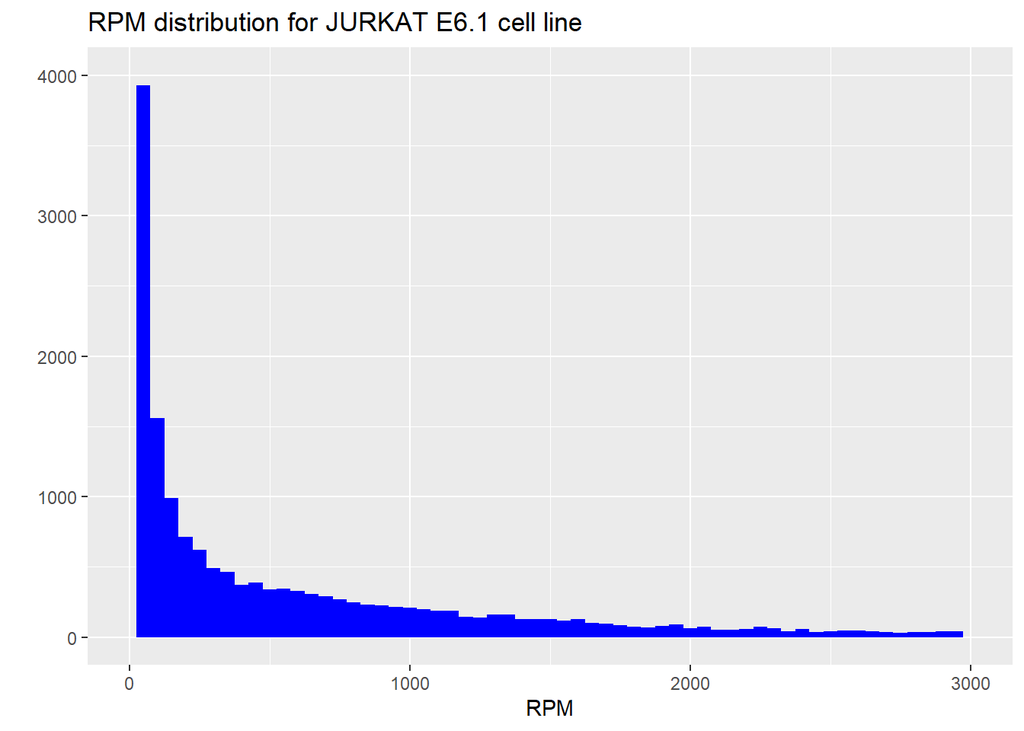

```r
qplot(cell_line$V2,
      geom="histogram",
      binwidth = 50,
      main = "RPM distribution for JURKAT E6.1 cell line",
      xlab = "RPM",
      fill=I("blue"),
      xlim=c(0,3000),
      ylim=c(0,4000))
```

```r
cell_line = read.delim("SRR2166637.htseq", header=F)
cell_line <- cell_line[cell_line$V2 != 0,]
```

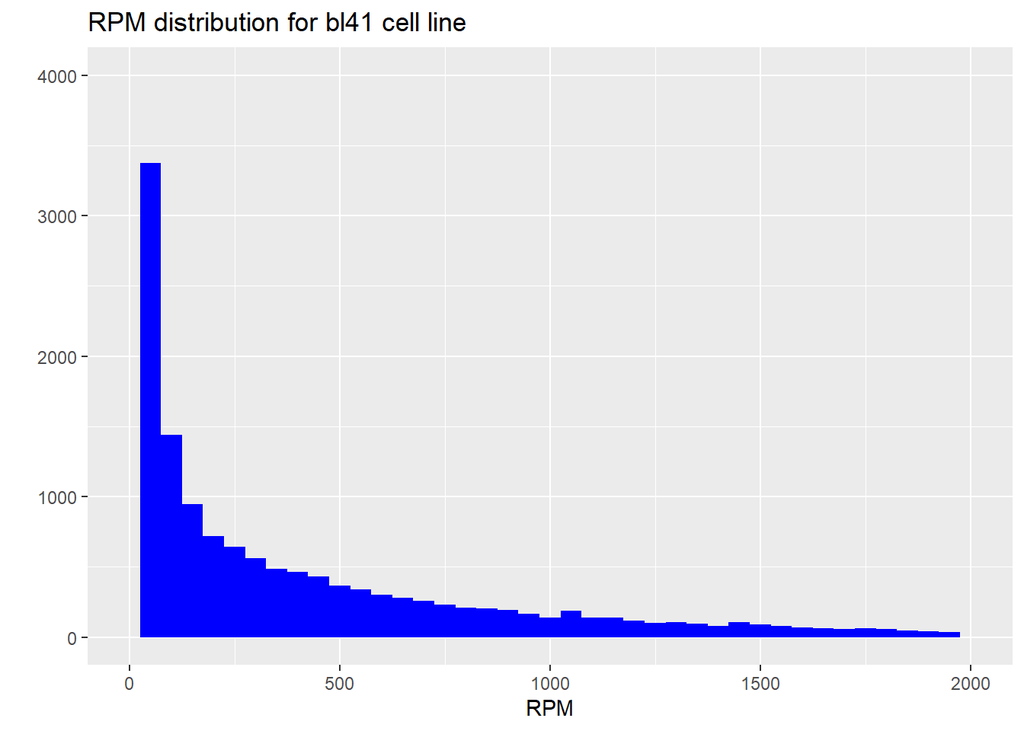

```r
qplot(cell_line$V2,
      geom="histogram",
      binwidth = 50,
      main = "RPM distribution for bl41 cell line",
      xlab = "RPM",
      fill=I("blue"),
      xlim=c(0,2000),
      ylim=c(0,4000))
```

```r
cell_line = read.delim("SRR2166638.htseq", header=F)
cell_line <- cell_line[cell_line$V2 != 0,]
```

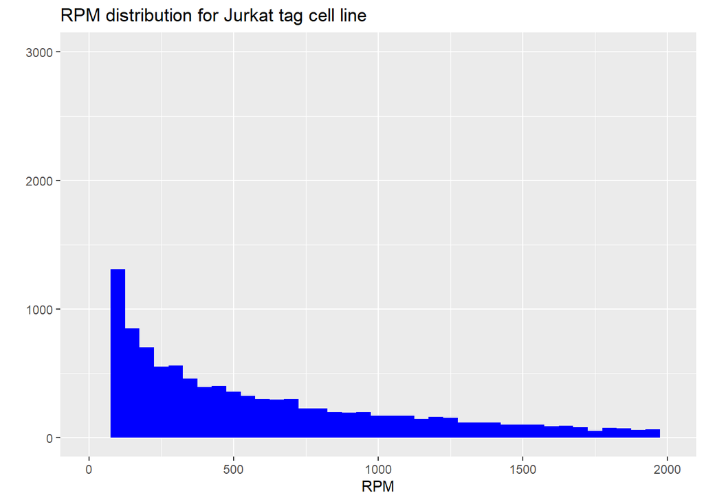

```r
qplot(cell_line$V2,
      geom="histogram",
      binwidth = 50,
      main = "RPM distribution for Jurkat tag cell line",
      xlab = "RPM",
      fill=I("blue"),
      xlim=c(0,2000),
      ylim=c(0,3000))
```

## Bar Plot

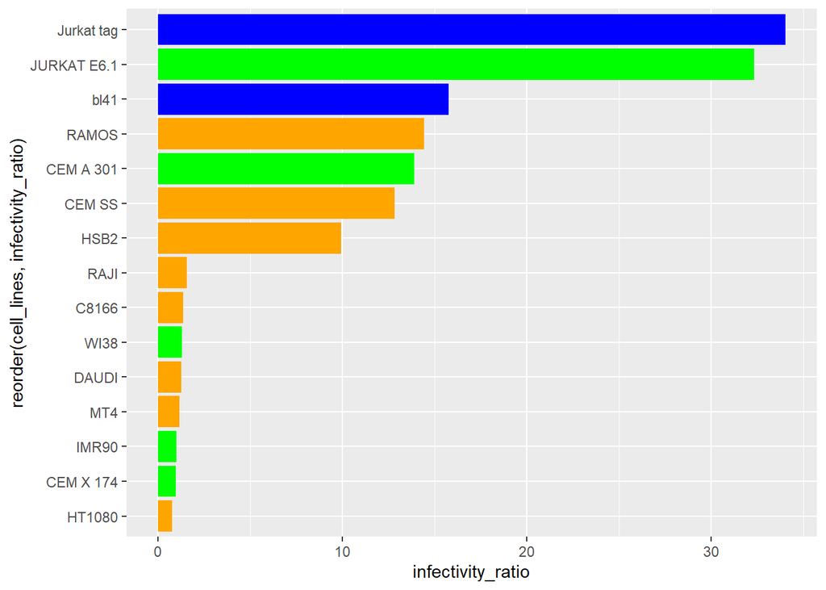

```r
ggplot(data = infect, aes(x= reorder(cell_lines, infectivity_ratio), y= infectivity_ratio))+geom_bar(stat = "identity", fill=c("orange", "orange", "orange", "orange", "orange", "orange", "orange", "orange", "green", "green", "green", "green", "green", "blue", "blue" ))+ coord_flip()
```

### Normalizing the datasets

Here we are making function to convert reads into normal reads per million

```r
Normaliser <- function(x){
  x/(sum(x)/1000000)
}
```

Using the above function in our samples dataset

```r
samples[,2:16] <- lapply(samples[,2:16], Normaliser)
```

### Dividing data into 6 subsets for better computation

```r
sample_1 <- samples[1:10000,]
sample_2 <- samples[10001:20000,]
sample_3 <- samples[20001: 30000,]
sample_4 <- samples[30001: 40000,]
sample_5 <- samples [40001: 50000,]
sample_6 <- samples [50001: 58307,]
```

### re-defing data

transposing the datasets

```r
sample_t_1 <- as.data.frame(t(sample_1))
names(sample_t_1) <- sample_t_1[1,]
sample_t_1 <- sample_t_1[-1,]

sample_t_2 <- as.data.frame(t(sample_2))
names(sample_t_2) <- sample_t_2[1,]
sample_t_2 <- sample_t_2[-1,]

sample_t_3 <- as.data.frame(t(sample_3))
names(sample_t_3) <- sample_t_3[1,]
sample_t_3 <- sample_t_3[-1,]

sample_t_4 <- as.data.frame(t(sample_4))
names(sample_t_4) <- sample_t_4[1,]
sample_t_4 <- sample_t_4[-1,]

sample_t_5 <- as.data.frame(t(sample_5))
names(sample_t_5) <- sample_t_5[1,]
sample_t_5 <- sample_t_5[-1,]

sample_t_6 <- as.data.frame(t(sample_6))
names(sample_t_6) <- sample_t_6[1,]
sample_t_6 <- sample_t_6[-1,]
```

```r
sample_t_1_infect <- data.frame(infect$infectivity_ratio ,sample_t_1)
sample_t_2_infect <- data.frame(infect$infectivity_ratio ,sample_t_2)
sample_t_3_infect <- data.frame(infect$infectivity_ratio ,sample_t_3)
sample_t_4_infect <- data.frame(infect$infectivity_ratio ,sample_t_4)
sample_t_5_infect <- data.frame(infect$infectivity_ratio ,sample_t_5)
sample_t_6_infect <- data.frame(infect$infectivity_ratio ,sample_t_6)
```

## creating data frame which will use in doing correlation test

```r
samples_t <- as.data.frame(t(samples))
names(samples_t) <- samples_t[1,]
samples_t <- samples_t[-1,]

samples_infect <- data.frame(infect$infectivity_ratio ,samples_t)
```

## correlation test

```r
i <- c()
cor_e <- c()
cor_p <- c()

for (i in 2:58308)
{
  m = cor.test(samples_infect[,1],as.numeric(samples_infect[,i]),method = 'spearman', use = 'pairwise.complete.obs',p.adjust.methods = "fdr", exact = F)
  cor_e[i-1] = m$estimate
  cor_p[i-1] = m$p.value
}

cor_test <- data.frame(Gene = colnames(samples_infect[,2:58308]),
                          cor_value = cor_e,
                          p_value = cor_p
                          )

cor_test <- na.omit(cor_test)

#cor_test
```

## subseting genes of interest

```r
gene_of_interest <- na.omit(cor_test[cor_test$cor_value > 0.7 & cor_test$p_value < 0.01 ,])
gene_of_interest
```

```
##                  Gene cor_value      p_value
## 14    ENSG00000001561 0.7035714 3.424337e-03
## 181   ENSG00000007350 0.7453940 1.424820e-03
## 196   ENSG00000007952 0.8357143 1.044469e-04
## 355   ENSG00000015133 0.7035714 3.424337e-03
## 631   ENSG00000047662 0.7035714 3.424337e-03
## 654   ENSG00000049167 0.7321429 1.912964e-03
## 772   ENSG00000057468 0.7107143 2.978995e-03
## 913   ENSG00000065060 0.7035714 3.424337e-03
## 923   ENSG00000065328 0.7464286 1.391411e-03
## 944   ENSG00000065675 0.7214286 2.398868e-03
## 1110  ENSG00000070388 0.7063350 3.246150e-03
## 1120  ENSG00000070601 0.7456984 1.414923e-03
## 1185  ENSG00000072201 0.7035714 3.424337e-03
## 1349  ENSG00000076555 0.7178571 2.581165e-03
```

[output cut: 355 more lines]

## correlation test

```r
i <- c()
cor_e <- c()
cor_p <- c()

for (i in 2:58308)
{
  m = cor.test(samples_infect[,1],as.numeric(samples_infect[,i]),method = 'pearson', use = 'pairwise.complete.obs',p.adjust.methods = "fdr", exact = F)
  cor_e[i-1] = m$estimate
  cor_p[i-1] = m$p.value
}

cor_test <- data.frame(Gene = colnames(samples_infect[,2:58308]),
                          cor_value = cor_e,
                          p_value = cor_p
                          )

#cor_test
```

## subseting genes of interest

```r
gene_of_interest <- na.omit(cor_test[cor_test$cor_value > 0.9 & cor_test$p_value < 0.01 ,])
gene_of_interest
```

```
##                  Gene cor_value      p_value
## 9778  ENSG00000154537 0.9254256 7.705474e-07
## 10269 ENSG00000158813 0.9019888 4.296749e-06
## 11315 ENSG00000164300 0.9194246 1.255658e-06
## 13429 ENSG00000172995 0.9005775 4.698709e-06
## 29794 ENSG00000230830 0.9046848 3.608298e-06
## 36137 ENSG00000241537 0.9190814 1.289741e-06
## 46552 ENSG00000260966 0.9006792 4.668736e-06
## 47792 ENSG00000263818 0.9107026 2.396988e-06
## 50568 ENSG00000269802 0.9172384 1.486291e-06
## 51770 ENSG00000271776 0.9030633 4.010310e-06
```

## SERINC5

**To recreate the results from the paper, we need to look at the correlation value SERINC5**  
Ensemble ID of **SERINC5** is ENSG00000164300 and from the table above, we can see that it has a correlation value of 0.91.

Now we replicate he Figure 1-d from the paper…

```r
Serinc5 <- samples_infect[, colnames(samples_infect) == c("infect.infectivity_ratio", "ENSG00000164300")]
```

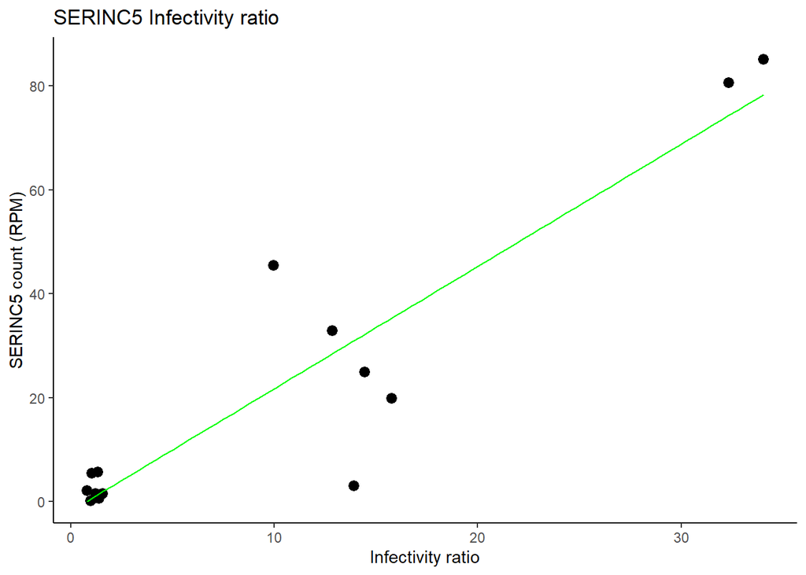

```r
ggplot(data = Serinc5, aes(infect.infectivity_ratio, as.numeric(ENSG00000164300), size= 1.0))+
geom_point(pch=20)+
geom_smooth(method = "lm", se=F, col="green", size=0.5)+
xlab("Infectivity ratio")+
ylab("SERINC5 count (RPM)")+
ggtitle("SERINC5 Infectivity ratio")+
geom_smooth(method = "lm", se=F, col="green", size=0.5)+
theme_classic()+
theme(legend.position = "none")
```

**We can also plot the infectivity ratio vs. RPM graph for all the SERNIC genes**  
SERINC1 ENSG00000111897  
SERINC2 ENSG00000168528  
SERINC3 ENSG00000132824  
SERINC4 ENSG00000184716  
SERINC5 ENSG00000164300

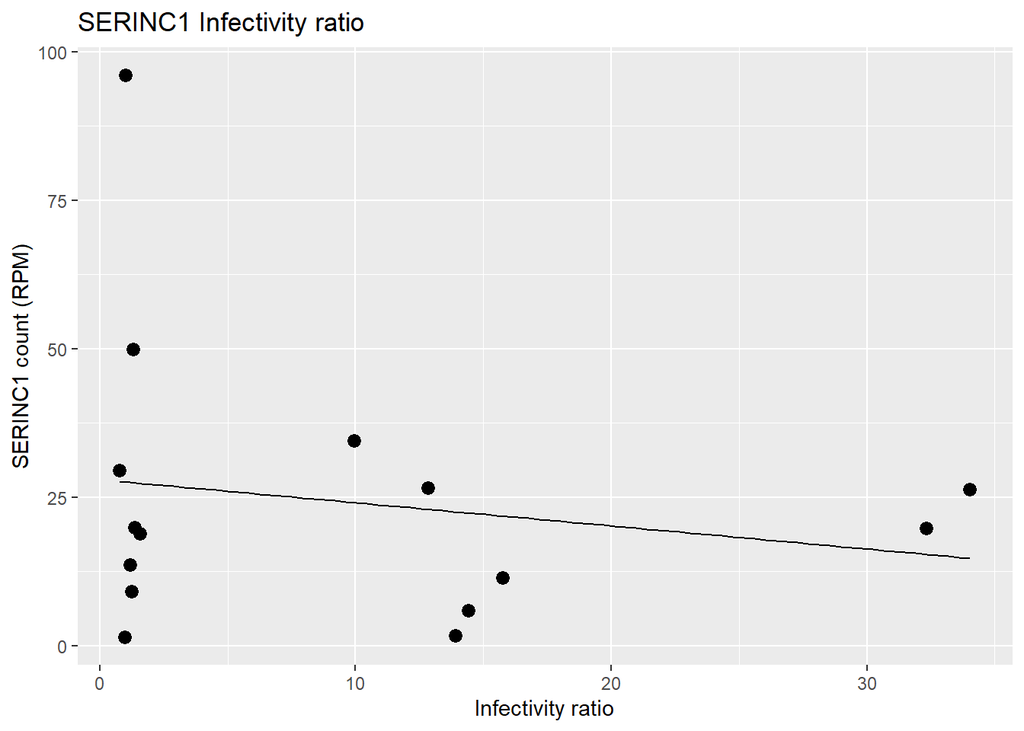

```r
ggplot(data = samples_infect, aes(infect.infectivity_ratio, as.numeric(ENSG00000111897), size= 1.0))+
geom_point(pch=20, col="black")+
geom_smooth(method = "lm", se=F, col="black", size=0.5)+
xlab("Infectivity ratio")+
ylab("SERINC1 count (RPM)")+
ggtitle("SERINC1 Infectivity ratio")+
theme(legend.position = "none")
```

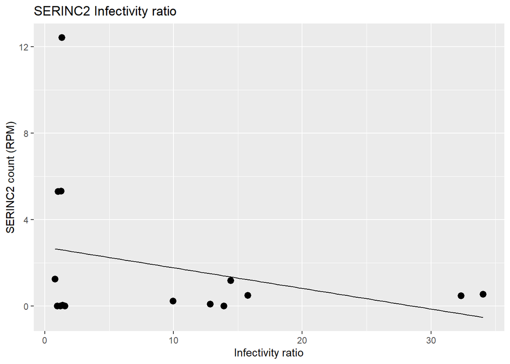

```r
ggplot(data = samples_infect, aes(infect.infectivity_ratio, as.numeric(ENSG00000168528), size= 1.0))+
geom_point(pch=20, col="black")+
geom_smooth(method = "lm", se=F, col="black", size=0.5)+
xlab("Infectivity ratio")+
ylab("SERINC2 count (RPM)")+
ggtitle("SERINC2 Infectivity ratio")+
theme(legend.position = "none")
```

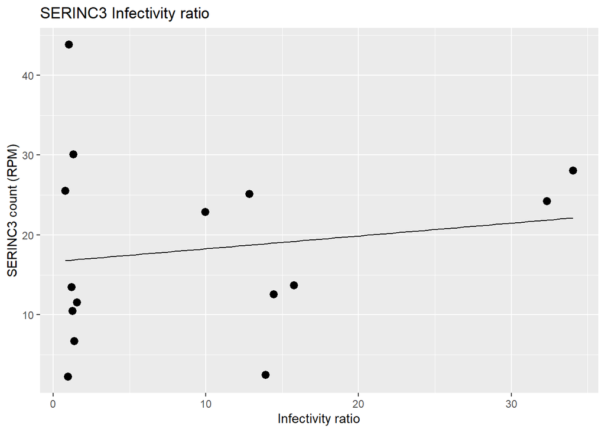

```r
ggplot(data = samples_infect, aes(infect.infectivity_ratio, as.numeric(ENSG00000132824), size= 1.0))+
geom_point(pch=20, col="black")+
geom_smooth(method = "lm", se=F, col="black", size=0.5)+
xlab("Infectivity ratio")+
ylab("SERINC3 count (RPM)")+
ggtitle("SERINC3 Infectivity ratio")+
theme(legend.position = "none")
```

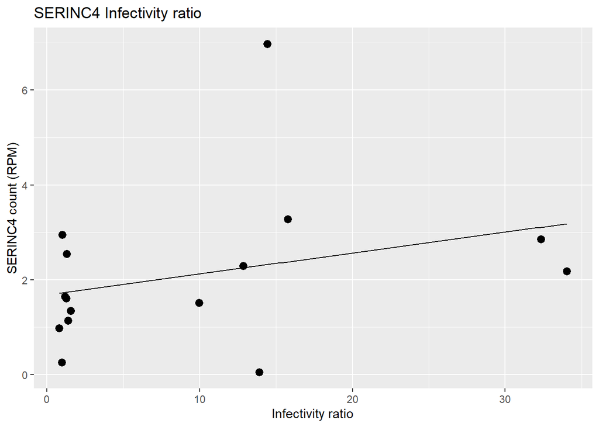

```r
ggplot(data = samples_infect, aes(infect.infectivity_ratio, as.numeric(ENSG00000184716), size= 1.0))+
geom_point(pch=20, col="black")+
geom_smooth(method = "lm", se=F, col="black", size=0.5)+
xlab("Infectivity ratio")+
ylab("SERINC4 count (RPM)")+
ggtitle("SERINC4 Infectivity ratio")+
theme(legend.position = "none")
```

## Next we find the genes with positive correlation as well as the genes with negative correlation

```r
poscor <- cor_test[cor_test$cor_value >= 0.9 & cor_test$p_value <= 0.01,] # For positively correlated genes
posgenenames<- poscor$Gene
posgenes <- samples_infect[, posgenenames]
```

```
## Error in `[.data.frame`(samples_infect, , posgenenames): undefined columns selected
```

```r
posgenes <- t(posgenes)
```

```
## Error in t(posgenes): object 'posgenes' not found
```

```r
negcor <- cor_test[cor_test$cor_value <= -0.6 & cor_test$p_value <= 0.05,] #For negatively correlated genes
neggenenames<- negcor$Gene
neggenes <- samples_infect[, neggenenames]
```

```
## Error in `[.data.frame`(samples_infect, , neggenenames): undefined columns selected
```

```r
neggenes <- t(neggenes)
```

```
## Error in t(neggenes): object 'neggenes' not found
```

```r
head(poscor, n=11L)
```

[output not shown]

```r
head(negcor, n=12L)
```

[output not shown]

# Our Hypothesis

The following genes might be able to block HIV as well… **SAMHD1 (ENSG00000101347):** **APOBEC3G (ENSG00000239713):** **MX2 (ENSG00000183486):** **TRIM5 (ENSG00000132256):** **Tethering (ENSG00000130303):** Blocs HIV Budding

## Generating the data

```r
SAMHD1 <- cor_test[cor_test$Gene=="ENSG00000101347",]
SAMHD1$cor_value
```

```
## [1] -0.4216684
```

```r
APOBEC3G <- cor_test[cor_test$Gene=="ENSG00000239713",]
APOBEC3G$cor_value
```

```
## [1] -0.1196492
```

```r
MX2 <- cor_test[cor_test$Gene=="ENSG00000183486",]
MX2$cor_value
```

```
## [1] 0.5551704
```

```r
TRIM5 <- cor_test[cor_test$Gene=="ENSG00000132256",]
TRIM5$cor_value
```

```
## [1] -0.1989562
```

```r
TETHERIN <- cor_test[cor_test$Gene=="ENSG00000130303",]
TETHERIN$cor_value
```

```
## [1] -0.2239895
```

```r
MX2 <- samples_infect[, colnames(samples_infect) == c("infect.infectivity_ratio", "ENSG00000183486")]
```

Now Plotting

[figure not shown]

```r
ggplot(data = MX2, aes(infect.infectivity_ratio, as.numeric(ENSG00000183486), size= 1.0))+
geom_point(pch=20)+
geom_smooth(method = "lm", se=F, col="black", size=0.5)+
xlab("Infectivity ratio")+
ylab("Tetherin count (RPM)")+
ggtitle("MX2 Infectivity ratio")+
geom_smooth(method = "lm", se=F, col="black", size=0.5)+
theme(legend.position = "none")
```

## Upregulatd genes

```r
head(poscor)
```

```
##      Gene cor_value p_value
## NA   <NA>        NA      NA
## NA.1 <NA>        NA      NA
## NA.2 <NA>        NA      NA
## NA.3 <NA>        NA      NA
## NA.4 <NA>        NA      NA
## NA.5 <NA>        NA      NA
```

ENSG00000158813 EDA  
ENSG00000269802 AC011491.3

### EDA [ENSG00000158813]

**About EDA:** The protein encoded by this gene is a type II membrane protein that can be cleaved by furin to produce a secreted form.  
**Hypothesis:** Upon infection with HIV, envelope proteins are attached to cell membrane so the fully packaged HIV with capcid can go and attached to cell membrane and leave the cell to infect new cell. So it might be upregulating this gene in order to increase it’s infectivity.

```r
EDA <- samples_infect[, colnames(samples_infect) == c("infect.infectivity_ratio", "ENSG00000158813")]
```

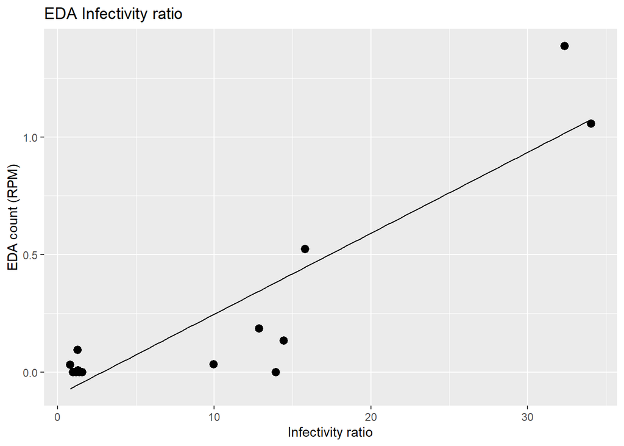

```r
ggplot(data = EDA, aes(infect.infectivity_ratio, as.numeric(ENSG00000158813), size= 1.0))+
geom_point(pch=20)+
geom_smooth(method = "lm", se=F, col="black", size=0.5)+
xlab("Infectivity ratio")+
ylab("EDA count (RPM)")+
ggtitle("EDA Infectivity ratio")+
theme(legend.position = "none")
```

## Down regulated genes

```r
head(negcor)
```

```
##      Gene cor_value p_value
## NA   <NA>        NA      NA
## NA.1 <NA>        NA      NA
## NA.2 <NA>        NA      NA
## NA.3 <NA>        NA      NA
## NA.4 <NA>        NA      NA
## NA.5 <NA>        NA      NA
```

```r
PLXNB2 <- samples_infect[, colnames(samples_infect) == c("infect.infectivity_ratio", "ENSG00000196576")]
```

Now Plotting

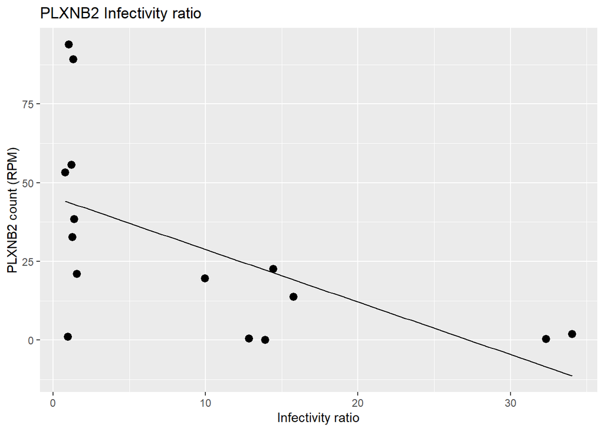

```r
ggplot(data = PLXNB2, aes(infect.infectivity_ratio, as.numeric(ENSG00000196576), size= 1.0))+
geom_point(pch=20)+
geom_smooth(method = "lm", se=F, col="black", size=0.5)+
xlab("Infectivity ratio")+
ylab("PLXNB2 count (RPM)")+
ggtitle("PLXNB2 Infectivity ratio")+
theme(legend.position = "none")
```